# Undernutrition Project

Marissa Piteo

7/13/2020

## Visualizing, Summarising, and Modeling Important Factors for Global Undernutrition

Creating compelling visuals that show the world’s most undernourished countries, and modeling the most important factors and short comings of these nations.

# Introduction

World hunger is a major problem throughout the world. There is a significant number of people, around 1.02 billion, fighting for their lives due to hunger and issues arising from being undernourished. It is a major cause of death and is related to many other diseases, such as heart issues. Hunger is a condition where individuals lack the nutrients they need such as calories, protein, and fat in order to be healthy and function daily. Undernutrition is the result of deficiencies of nutrients due to this extreme hunger. Although there are many causes of hunger and undernutriton, a major one is economic instability. Poverty plays a large role in people’s fight for addressing their nutrition issues and hunger. There are 1.2 billion people living on less than a dollar a day who cannot afford food or the essentials for healthy living. Many countries who face particularly intense hunger are provided with programs and donations through various organizations such as Action Against Hunger (AAH). Due to the importance of world hunger/undernourishment and the detramental effects it has on many people throughout the world, this project is to demonstarte relationships between undernourishment throughout the world with factors effecting, helping, and contributing to it. This project code looks at data of undernourished individuals in countries throughout the world, visualize this data through maps with gradients, compare fat, protein, and calories to the percentage of undernourished people in these countries, look at poverty rates compared to percentage of undernourished individuals in these countries, and look at how organizations, specifically AAH, impact in aiding in undernourishment in the top most undernurished countries.

# Required Packages

These are the r packages required for this project.

```r
library(dplyr)
library(ggplot2)
library(maptools)
library(viridisLite)
library(tidymodels)
```

# Reading in Raw Data

This section of code reads in the raw data that contains the number of undernourished people in each country over time. It removes larger regions and repeats so that it is specific only to each country.

```r
World_Malnutrition_Numbers <- read.csv('/Users/marissapiteo/Downloads/number-undernourished.csv')
World_Malnutrition_Numbers <- World_Malnutrition_Numbers[order(-World_Malnutrition_Numbers$Suite.of.Food.Security.Indicators...Number.of.people.undernourished..million...3.year.average....210011...Value...6132...millions..people.),]
To_be_removed <- c('Africa', 'Asia', 'Asia, Central', 'Caribbean', 'Central America', 'Central and Southern Asia', 'East Asia (exc China)', 'Eastern Africa', 'Eastern and South-Eastern Asia', 'Eastern Asia', 'Eastern Europe', 'Land Locked Developing Countries', 'Latin America and the Caribbean', 'Least Developed Countries', 'Low income', 'Low Income Food Deficit Countries', 'Lower middle income', 'Middle Africa', 'North Africa (exc Sudan)', 'Northern Africa', 'Northern Africa and Western Asia', 'Oceania', 'Small island developing States', 'South America', 'South Asia (exc India)', 'South Eastern Asia', 'Southern Africa', 'Southern Asia', 'Sub-Saharan Africa', 'Sub-Saharan Africa (inc. Sudan)','Upper middle income', 'Western Africa', 'Western Asia', 'World')
Country_Malnutrition_Numbers <- filter(World_Malnutrition_Numbers, !Entity %in% To_be_removed)
Country_Malnutrition_Numbers <- filter(Country_Malnutrition_Numbers, Code != '')
Country_Malnutrition_Numbers <- rename(Country_Malnutrition_Numbers, "Number of People Undernourished" = "Suite.of.Food.Security.Indicators...Number.of.people.undernourished..million...3.year.average....210011...Value...6132...millions..people.")
head(Country_Malnutrition_Numbers)
```

```
##   Entity Code Year Number of People Undernourished
## 1  India  IND 2004                       256500000
## 2  India  IND 2005                       253900000
## 3  India  IND 2003                       246500000
## 4  India  IND 2006                       241100000
## 5  India  IND 2002                       229300000
## 6  India  IND 2007                       225900000
```

# Summarizing Raw Data as an Average

This section of code takes the data and averages all of the years and gives an average of the five years (2013-2017). Then it converts it to a log scale.

```r
Country_Malnutrition_Numbers <- filter(Country_Malnutrition_Numbers, Year > 2012)
Country_Averages <- Country_Malnutrition_Numbers %>%
                                 group_by(Entity) %>%
                                 summarise(Average_Log=sum(`Number of People Undernourished`/5))
Country_Averages <- as.data.frame(Country_Averages)
Country_Averages <- Country_Averages[order(-Country_Averages$Average_Log),]
Country_Averages[2] <- log10(Country_Averages[2])
Country_Malnutrition_Numbers <- left_join(Country_Malnutrition_Numbers, Country_Averages, by = 'Entity')
head(Country_Malnutrition_Numbers)
```

```
##   Entity Code Year Number of People Undernourished Average_Log
## 1  India  IND 2013                       216300000    8.309928
## 2  India  IND 2014                       210400000    8.309928
## 3  India  IND 2015                       202700000    8.309928
## 4  India  IND 2016                       196900000    8.309928
## 5  India  IND 2017                       194400000    8.309928
## 6  China  CHN 2013                       137700000    8.105987
```

# Visualizing World Hunger in a Map

This section makes the world map with color gradient from most to least undernourished.

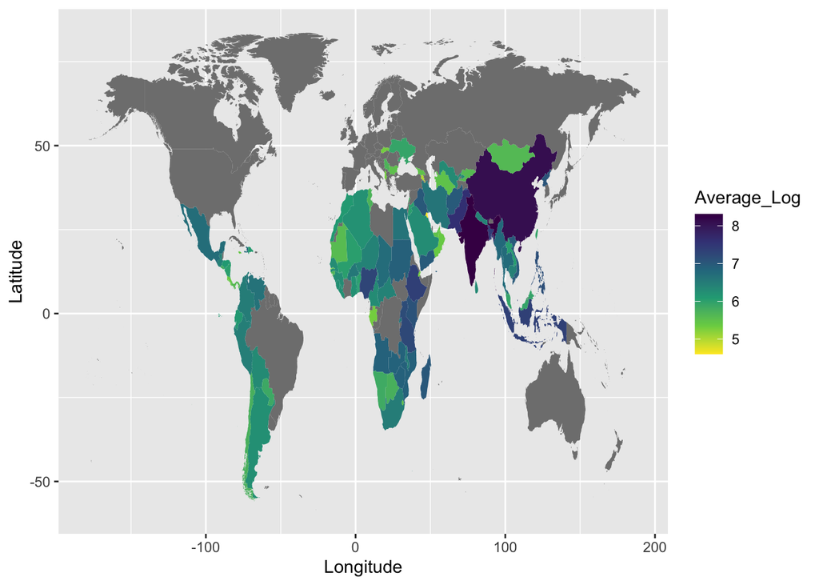

```r
world_map <- map_data('world')
world_map <- filter(world_map, region != 'Antarctica')
map_hunger_df <- left_join(world_map, Country_Averages, by = c('region' = 'Entity'))
ggplot(data = map_hunger_df, aes(x = long, y = lat, group = group)) +
  geom_polygon(aes(fill = Average_Log)) +
  scale_fill_viridis_c(direction = -1) +
  labs(x = 'Longitude', y = 'Latitude')
```

```r
ggsave("World.Hunger.Map.png")
```

# Highlighting the Top 10

This section edits to make the map with a color gradient of only the top ten most undernourished countries for future graphs.

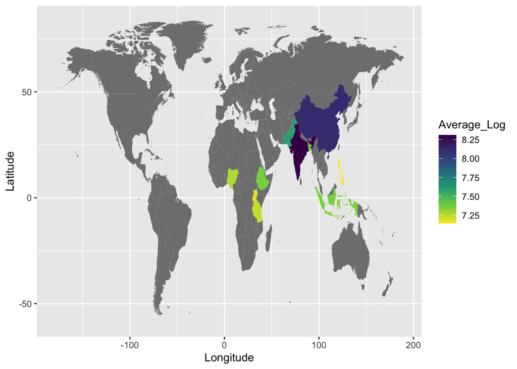

```r
Top_10 <- slice(Country_Averages, (1:10))
Top_10_Map <- left_join(world_map, Top_10, by = c('region' = 'Entity'))
ggplot(data = Top_10_Map, aes(x = long, y = lat, group = group)) +
  geom_polygon(aes(fill = Average_Log)) +
  scale_fill_viridis_c(direction = -1) +
  labs(x = 'Longitude', y = 'Latitude')
```

```r
ggsave("Top.10.Countries.Hunger.Map.png")
```

# Adjusting Data to Represent Percentage

This section of code creates a new table that will be expanded on in order to represent a more complete view of what it means to be undernourished. It also adds in the population for each country from 2016 with a percentage of each population that is undernourished.

```r
Undernutrition_Profile <- Country_Malnutrition_Numbers %>%
  group_by(Entity) %>%
  summarise(Average=sum(`Number of People Undernourished`/5))
Undernutrition_Profile <- as.data.frame(Undernutrition_Profile)
Undernutrition_Profile <- Undernutrition_Profile[order(-Undernutrition_Profile$Average),]
Country_Populations <- read.csv('/Users/marissapiteo/Downloads/population-figures-by-country-csv_csv.csv')
Country_Populations <- select(Country_Populations, Country, Year_2016)
Undernutrition_Profile <- left_join(Country_Populations, Undernutrition_Profile, by = c('Country'= 'Entity')) %>%
  na.omit()
Undernutrition_Profile <- rename(Undernutrition_Profile, 'Population' = 'Year_2016')
Undernutrition_Profile <- mutate(Undernutrition_Profile, Percentage = Average/Population * 100)
Undernutrition_Profile <- Undernutrition_Profile[order(-Undernutrition_Profile$Percentage),]
head(Undernutrition_Profile)
```

```
##                     Country Population Average Percentage
## 13 Central African Republic    4594621 2520000   54.84674
## 32                    Haiti   10847334 5260000   48.49118
## 86                 Zimbabwe   16150362 7660000   47.42928
## 85                   Zambia   16591390 7360000   44.36036
## 46               Madagascar   24894551 9880000   39.68740
## 42                  Liberia    4613823 1720000   37.27928
```

# Modeling the Importance of Calorie Availability

This section reads in data on the amount of calories available per person per day in each country. It puts it into a table, graphs it, and creates a linear aggression model comparing percent of population undernourished with number of calories available. The results show that with more available calories per person per day, there is a smaller percentage of undernourished individuals in these countries.

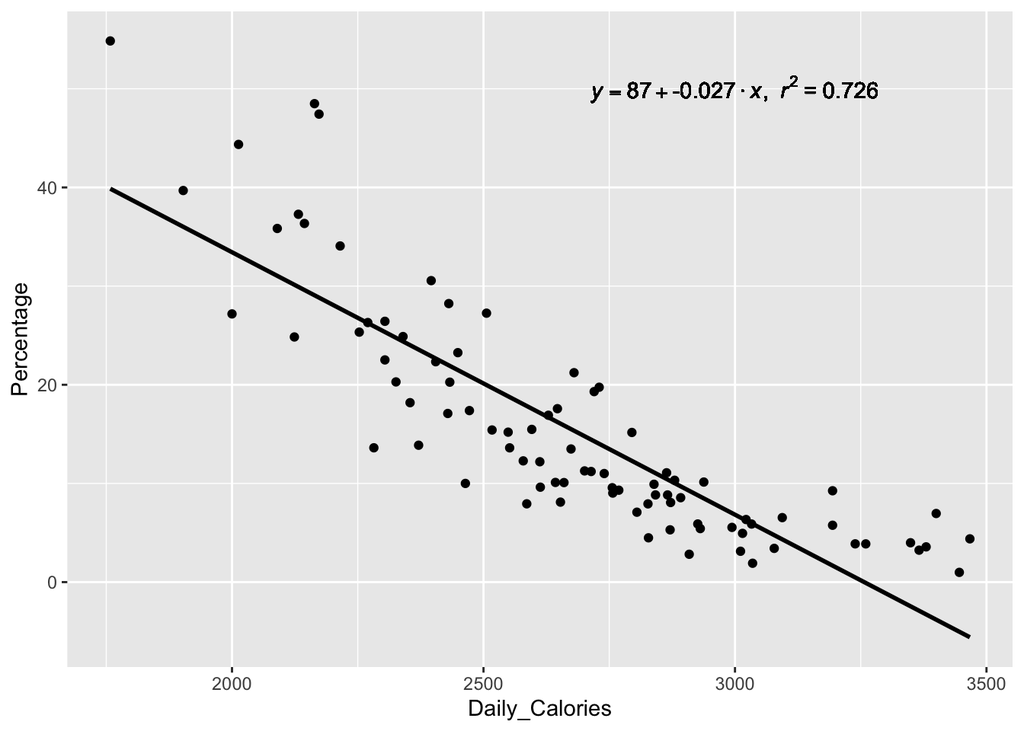

```r
Country_Calorie_Numbers <- read.csv('/Users/marissapiteo/Downloads/food-supply-kcal.csv')
Country_Calorie_Numbers <- filter(Country_Calorie_Numbers, Year == 2017)
Country_Calorie_Numbers <- rename(Country_Calorie_Numbers, 'Daily_Calories' = 'Daily.caloric.supply..kilocalories.per.person.per.day.')
Country_Calorie_Numbers <- select(Country_Calorie_Numbers, Entity, Daily_Calories)
Undernutrition_Profile <- left_join(Undernutrition_Profile, Country_Calorie_Numbers, by =c('Country'='Entity'))
Calorie_eqn <- function(Undernutrition_Profile){
  m <- lm(Percentage ~ Daily_Calories, Undernutrition_Profile);
  eq <- substitute(italic(y) == a + b %.% italic(x)*","~~italic(r)^2~"="~r2,
                   list(a = format(unname(coef(m)[1]), digits = 2),
                        b = format(unname(coef(m)[2]), digits = 2),
                        r2 = format(summary(m)$r.squared, digits = 3)))
  as.character(as.expression(eq));
}
ggplot(Undernutrition_Profile, aes(Daily_Calories, Percentage)) +
  geom_point() +
  geom_smooth(method = lm, se = FALSE, color = 'black') +
  geom_text(x = 3000, y = 50, label = Calorie_eqn(Undernutrition_Profile), parse = TRUE)
```

# Modeling the Importance of Fat Availability

This section reads in data on the amount of fat available per person per day in each country. It puts it into a table, graphs it, and creates a linear aggression model comparing percent of population undernourished with amount of fat available. The results show that with more available fat per person per day, there is a smaller percentage of undernourished individuals in these countries.

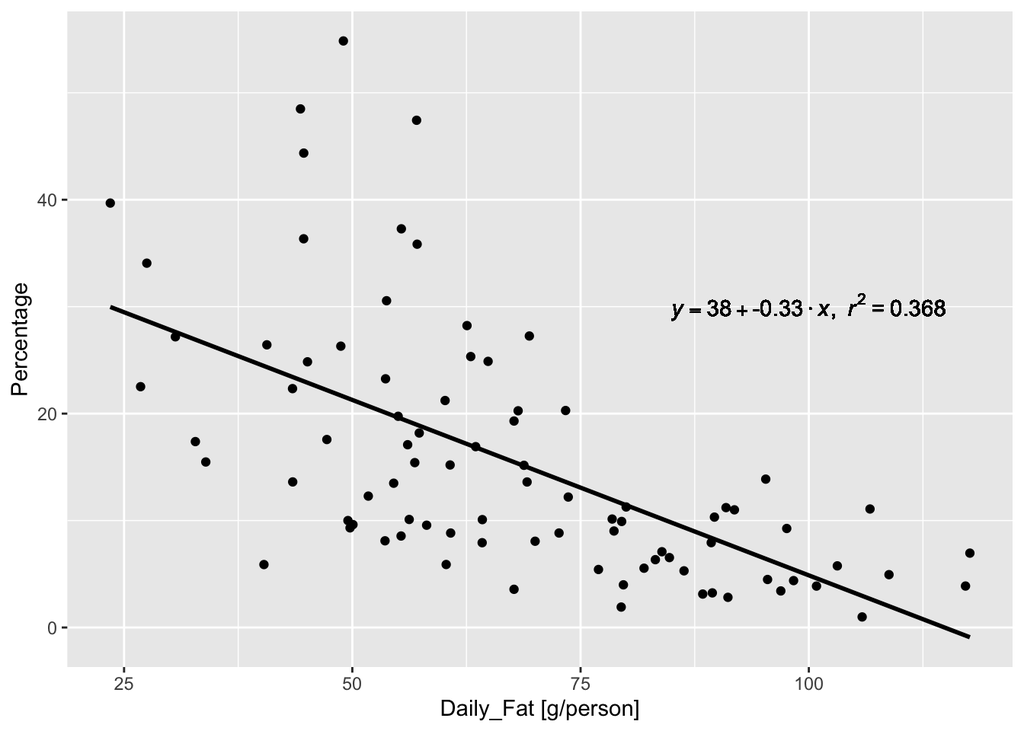

```r
Country_Fat_Numbers <- read.csv('/Users/marissapiteo/Downloads/daily-per-capita-fat-supply.csv')
Country_Fat_Numbers <- filter(Country_Fat_Numbers, Year == 2017)
Country_Fat_Numbers <- rename(Country_Fat_Numbers, 'Daily_Fat' = 'Daily.fat.supply..grams.per.person.per.day.')
Country_Fat_Numbers <- filter(Country_Fat_Numbers, Daily_Fat <120)
Country_Fat_Numbers <- select(Country_Fat_Numbers, 'Entity', 'Daily_Fat')
Undernutrition_Profile <- left_join(Undernutrition_Profile, Country_Fat_Numbers, by = c('Country'='Entity'))

Fat_eqn <- function(Undernutrition_Profile){
  m <- lm(Percentage ~ Daily_Fat, Undernutrition_Profile);
  eq <- substitute(italic(y) == a + b %.% italic(x)*","~~italic(r)^2~"="~r2,
                   list(a = format(unname(coef(m)[1]), digits = 2),
                        b = format(unname(coef(m)[2]), digits = 2),
                        r2 = format(summary(m)$r.squared, digits = 3)))
  as.character(as.expression(eq));
}
ggplot(Undernutrition_Profile, aes(Daily_Fat, Percentage)) +
  geom_point() +
  geom_smooth(method = lm, se = FALSE, color = 'black') +
  geom_text(x = 100, y = 30, label = Fat_eqn(Undernutrition_Profile), parse = TRUE) +
  labs(x = 'Daily_Fat [g/person]')
```

# Modeling the Importance of Protein Availability

This section reads in data on the amount of protein available per person per day in each country. It puts it into a table, graphs it, and creates a linear aggression model comparing percent of population undernourished with namount of protein available. The results show that with more availableprotein per person per day, there is a smaller percentage of undernourished individuals in these countries.

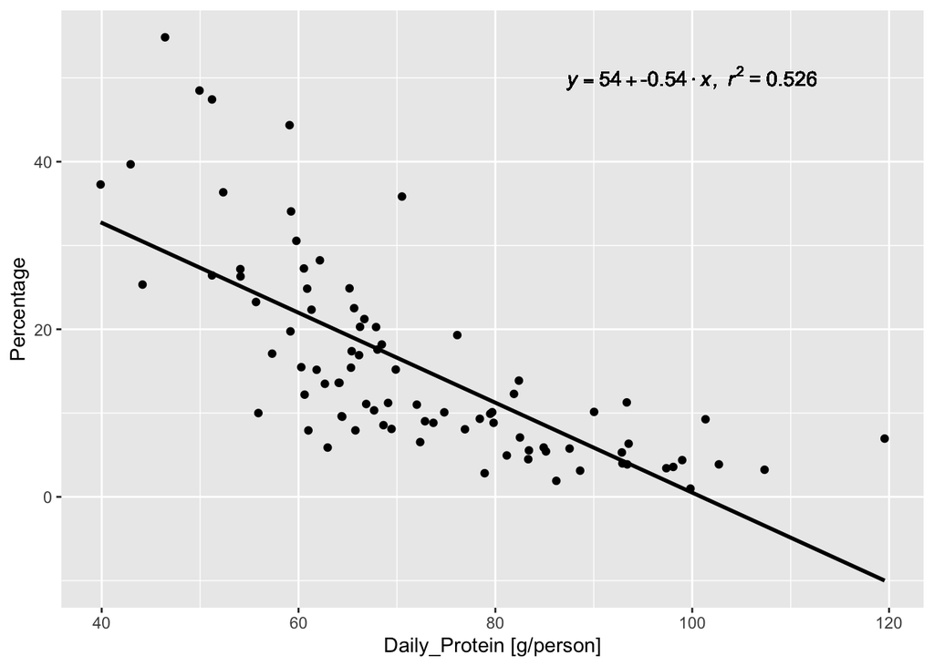

```r
Country_Protein_Numbers <- read.csv('/Users/marissapiteo/Downloads/daily-per-capita-protein-supply.csv')
Country_Protein_Numbers <- filter(Country_Protein_Numbers, Year == 2017)
Country_Protein_Numbers <- rename(Country_Protein_Numbers, 'Daily_Protein' = 'Daily.protein.supply..grams.per.person.per.day.')
Country_Protein_Numbers <- select(Country_Protein_Numbers, 'Entity', 'Daily_Protein')
Undernutrition_Profile <- left_join(Undernutrition_Profile, Country_Protein_Numbers, by = c('Country'='Entity'))

Protein_eqn <- function(Undernutrition_Profile){
  m <- lm(Percentage ~ Daily_Protein, Undernutrition_Profile);
  eq <- substitute(italic(y) == a + b %.% italic(x)*","~~italic(r)^2~"="~r2,
                   list(a = format(unname(coef(m)[1]), digits = 2),
                        b = format(unname(coef(m)[2]), digits = 2),
                        r2 = format(summary(m)$r.squared, digits = 3)))
  as.character(as.expression(eq));
}
ggplot(Undernutrition_Profile, aes(Daily_Protein, Percentage)) +
  geom_point() +
  geom_smooth(method = lm, se = FALSE, color = 'black') +
  geom_text(x = 100, y = 50, label = Protein_eqn(Undernutrition_Profile), parse = TRUE) +
  labs(x = 'Daily_Protein [g/person]')
```

# The Importance of Poverty

This section of code looks at how poverty relates to unernourished indiivduals in various countries. It adds a column about extreme poverty (under $1.90 a day). The data was not adequate for a model.

```r
Country_Poverty_Numbers <- read.csv('/Users/marissapiteo/Downloads/share-of-the-population-living-in-extreme-poverty.csv')
Country_Poverty_Numbers <- filter(Country_Poverty_Numbers, Year == 2011)
Country_Poverty_Numbers <- rename(Country_Poverty_Numbers, 'Percentage_Living_Under_$1.90' = 'Share.of.the.population.living.in.extreme.poverty....')
Country_Poverty_Numbers <- select(Country_Poverty_Numbers, 'Entity', 'Percentage_Living_Under_$1.90')
Undernutrition_Profile <- left_join(Undernutrition_Profile, Country_Poverty_Numbers, by = c('Country'='Entity'))
```

# Creating A Comprehensive Model

This section of code builds a linear regression model that predicts percentage of the population that is undernourished based on the calories, fat, and protein available. The results show that of the three factors used to create this model, the number of calories available is the most significant indicator, as is expected. This can be seen by the significantly smaller p value, in the resulting table of coefficients.

```r
Undernutrition_Model <- lm(Percentage ~ Daily_Calories + Daily_Fat + Daily_Protein, data = Undernutrition_Profile)
summary(Undernutrition_Model)$coefficient
```

```
##                   Estimate  Std. Error    t value     Pr(>|t|)
## (Intercept)    86.53316367 5.384940493 16.0694745 4.631918e-27
## Daily_Calories -0.02595751 0.003459572 -7.5030987 6.679560e-11
## Daily_Fat       0.01762934 0.047718462  0.3694449 7.127485e-01
## Daily_Protein  -0.03899244 0.082597883 -0.4720755 6.381267e-01
```

# Hope From Charities

This section of code creates a bar graph about the number of individuals helped by Action Against Hunger. It shows the top ten most undernourished countries in relation to the number of individuals from those countries that were helped by a nutrition program in 2018.China did not have data for this section. Although some countries reached a greater number of people, it is important to see the benefits of just one of the many organizations aiding in world hunger and undernourishment.

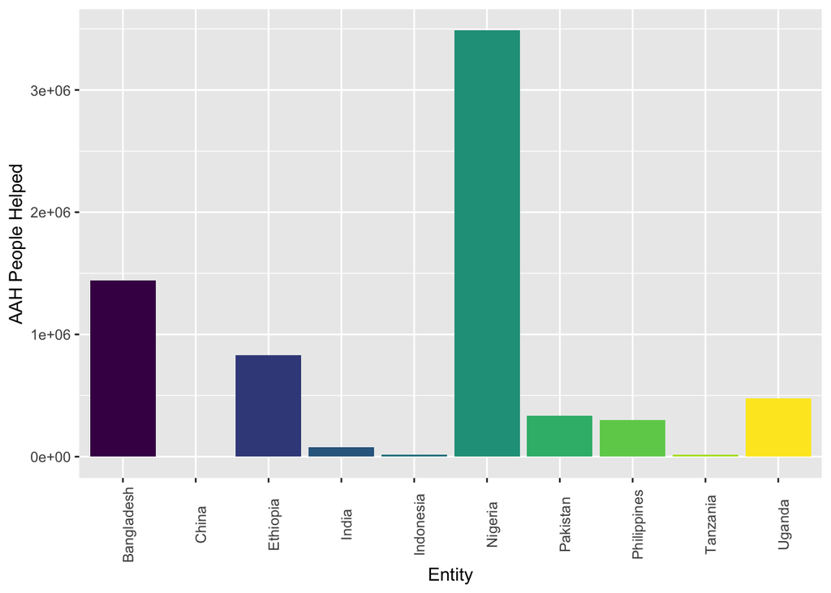

```r
People_Helped_by_AAH_2018 <- c(75530, 0, 334588, 1442297, 832829, 18641, 3488001, 14205, 474505, 302014)
Top_10 <- mutate(Top_10, People_Helped_by_AAH_2018)
ggplot(Top_10, aes(Entity, People_Helped_by_AAH_2018)) +
  geom_col(aes(fill = Entity)) +
  theme(axis.text.x = element_text(angle = 90), legend.position = 'none') +
  labs(y = 'AAH People Helped') +
  scale_fill_viridis_d()
```

# Citations

‘Country Undernutrition Data’ (Roser and Ritchie 2013b) ‘Food Availability Data’ (Roser and Ritchie 2013a) Population Data - https://datahub.io/JohnSnowLabs/population-figures-by-country/r/0.html Issues and challenges in defeating world hunger - World poverty and hunger-the challenge for science. - https://www-sciencedirect-com.ezproxy.stonehill.edu/science/article/pii/S0924224410001779 https://go-gale-com.ezproxy.stonehill.edu/ps/retrieve.do?tabID=T002&resultListType=RESULT_LIST&searchResultsType=SingleTab&searchType=BasicSearchForm&currentPosition=5&docId=GALE%7CA85241334&docType=Article&sort=Relevance&contentSegment=ZHCC&prodId=HRCA&contentSet=GALE%7CA85241334&searchId=R11&userGroupName=mlin_s_stonecol&inPS=true&ps=1&cp=5 ‘Poverty Data’ (Roser and Ortiz-Ospina 2013) AAH Data- https://www.actionagainsthunger.org/countries

Roser, Max, and Esteban Ortiz-Ospina. 2013. “Global Extreme Poverty.” *Our World in Data*.

Roser, Max, and Hannah Ritchie. 2013a. “Food Supply.” *Our World in Data*.

———. 2013b. “Hunger and Undernourishment.” *Our World in Data*.